# Loan Prediction

Rohit Dixit

# Problem Statement

Company wants to automate the loan eligibility process (real time) based on customer detail provided while filling online application form. These details are Gender, Marital Status, Education, Number of Dependents, Income, Loan Amount, Credit History and others. To automate this process, they have given a problem to identify the customers segments, those are eligible for loan amount so that they can specifically target these customers. Here they have provided a partial data set.

# Data Glimpse

| **Variable** | **Description** |
| --- | --- |
| Loan_ID | Unique Loan ID |
| Gender | Male/ Female |
| Married | Applicant married (Y/N) |
| Dependents | Number of dependents |
| Education | Applicant Education (Graduate/ Under Graduate) |
| Self_Employed | Self employed (Y/N) |
| ApplicantIncome | Applicant income |
| CoapplicantIncome | Coapplicant income |
| LoanAmount | Loan amount in thousands |
| Loan_Amount_Term | Term of loan in months |
| Credit_History | credit history meets guidelines |
| Property_Area | Urban/ Semi Urban/ Rural |
| Loan_Status Loan | approved (Y/N) |

## R Code

### Importing Library

```r
library(caret)
library(mlbench)
library(ggplot2)
library(ggthemes)
library(plyr)
library(RANN)
library(gridExtra)
library(Rmisc)
library(caTools)
library(DiagrammeR)
library(car)
library(doParallel)
library(randomForest)
```

### Importing Data

Data available at https://datahack-prod.s3.ap-south-1.amazonaws.com/train_file/train_u6lujuX_CVtuZ9i.csv

```r
data <- read.csv(url("https://datahack-prod.s3.ap-south-1.amazonaws.com/train_file/train_u6lujuX_CVtuZ9i.csv"))
```

# Data Exploration

```r
summary(data)
```

```
##      Loan_ID       Gender    Married   Dependents        Education
##  LP001002:  1         : 13      :  3     : 15     Graduate    :480
##  LP001003:  1   Female:112   No :213   0 :345     Not Graduate:134
##  LP001005:  1   Male  :489   Yes:398   1 :102
##  LP001006:  1                          2 :101
##  LP001008:  1                          3+: 51
##  LP001011:  1
##  (Other) :608
##  Self_Employed ApplicantIncome CoapplicantIncome   LoanAmount
##     : 32       Min.   :  150   Min.   :    0     Min.   :  9.0
##  No :500       1st Qu.: 2878   1st Qu.:    0     1st Qu.:100.0
##  Yes: 82       Median : 3812   Median : 1188     Median :128.0
##                Mean   : 5403   Mean   : 1621     Mean   :146.4
##                3rd Qu.: 5795   3rd Qu.: 2297     3rd Qu.:168.0
##                Max.   :81000   Max.   :41667     Max.   :700.0
##                                                  NA's   :22
##  Loan_Amount_Term Credit_History     Property_Area Loan_Status
##  Min.   : 12      Min.   :0.0000   Rural    :179   N:192
##  1st Qu.:360      1st Qu.:1.0000   Semiurban:233   Y:422
##  Median :360      Median :1.0000   Urban    :202
##  Mean   :342      Mean   :0.8422
##  3rd Qu.:360      3rd Qu.:1.0000
##  Max.   :480      Max.   :1.0000
##  NA's   :14       NA's   :50
```

The summary shows, we have NA values to handle let’s explore our data more.

## Exploring target variable-**Loan_Status**

```r
table(data$Loan_Status)
```

```
##
##   N   Y
## 192 422
```

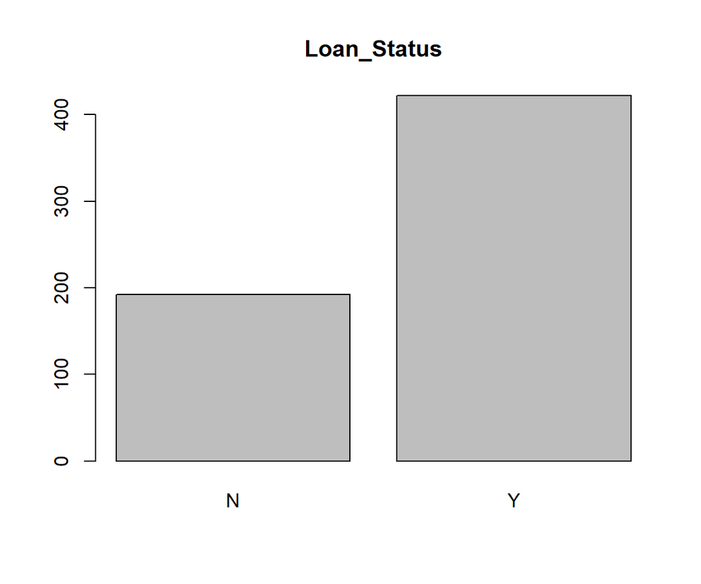

```r
barplot(table(data$Loan_Status),main= "Loan_Status")
```

## Exploring our Independent variables-

### 1. Gender

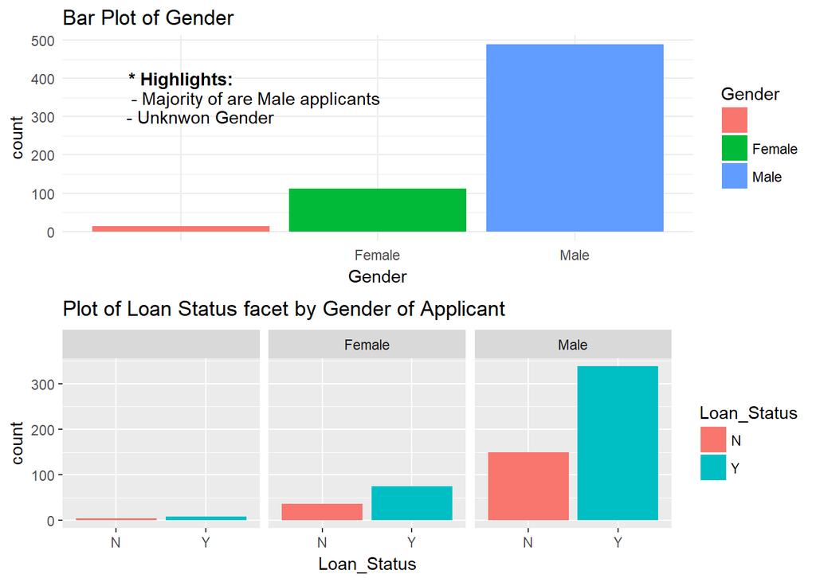

### 2. Married

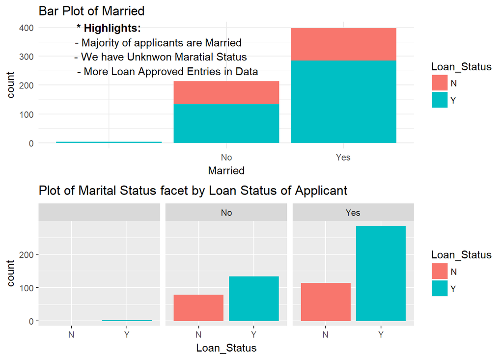

### 3. Dependents

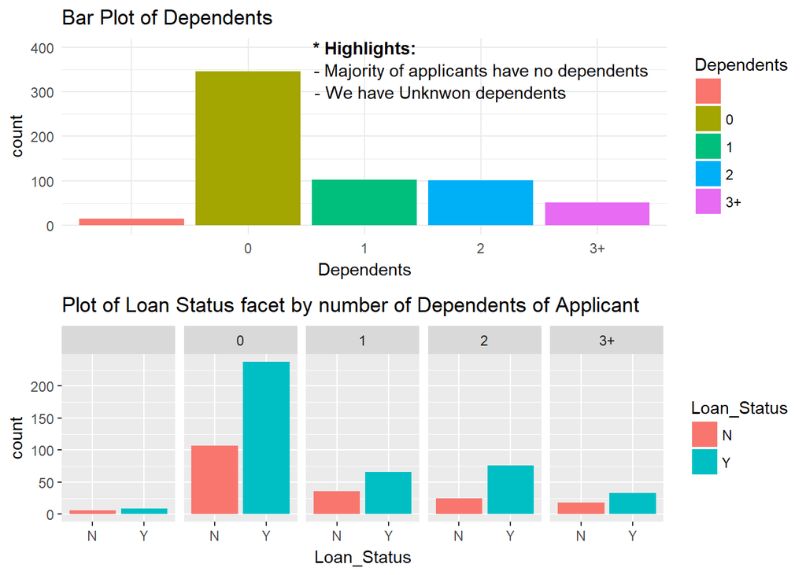

### 4. Education

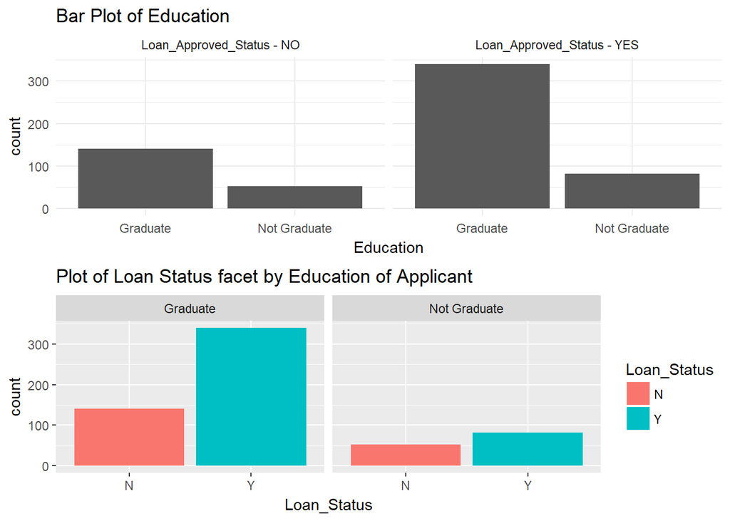

- Take Away points:
- Majority of are Graduates

### 5. Self_Employed

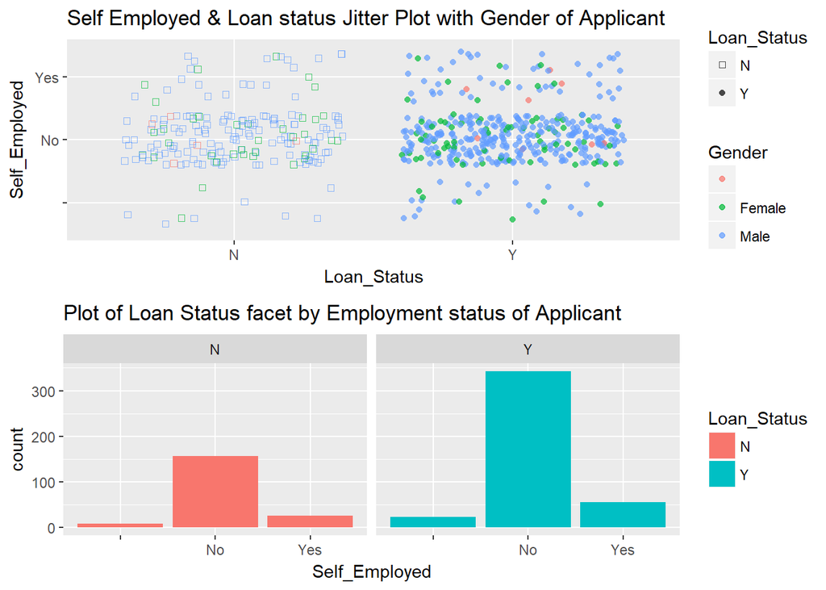

- Take Away points:
- Majority of applicants are not self employed
- We have Unknwon values, so preprocessing needed

### 6. ApplicantIncome (Numeric) & CoapplicantIncome (Numeric)

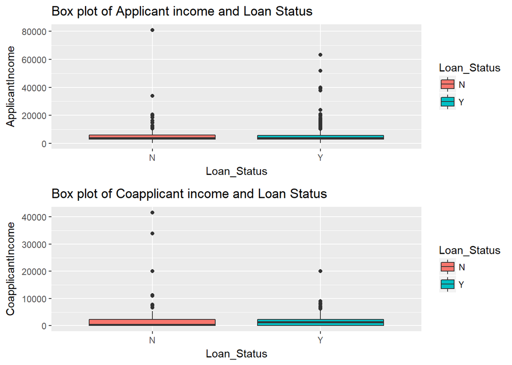

- Take Away points:
- Applicant Income box plot shows right skewness
- We have outliers so scaling and centering willl be needed

### 7. LoanAmount (Numeric)

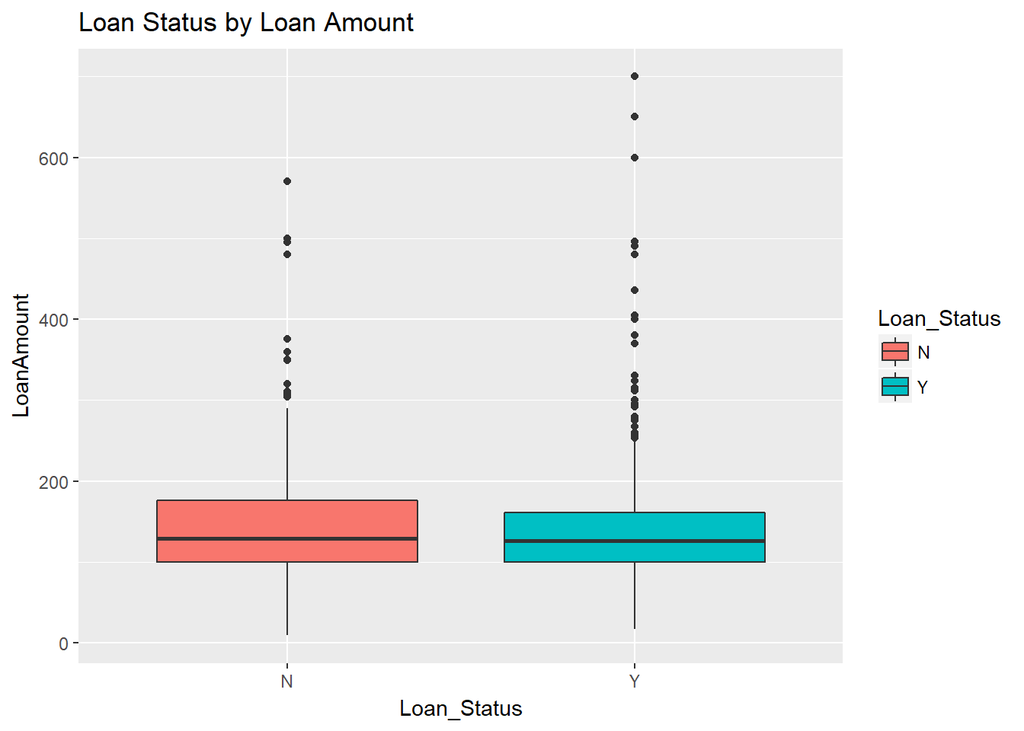

- Take Away points:
- Plots show right skewness
- We have outliers so scaling and centering willl be needed

### 8. Loan_Amount_Term (Numeric)

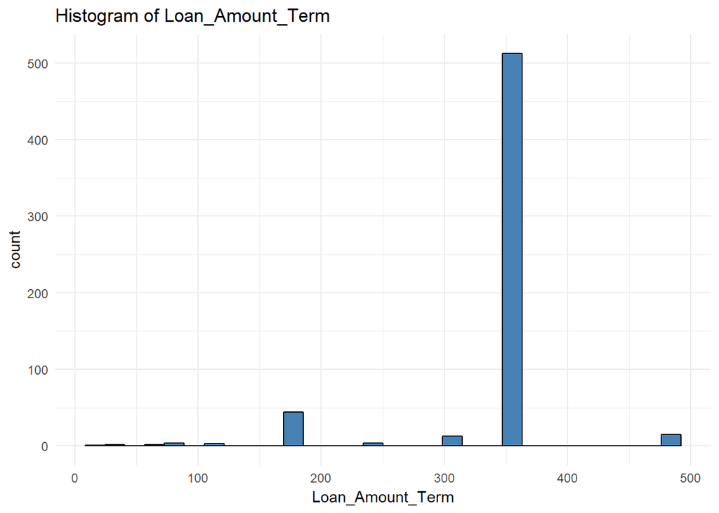

- Take Away points:
- Majority have 360 months as loan amount term
- We might have a few typo as 350 monts and 6 months tuple are present

### 9. Credit_History (Factor)

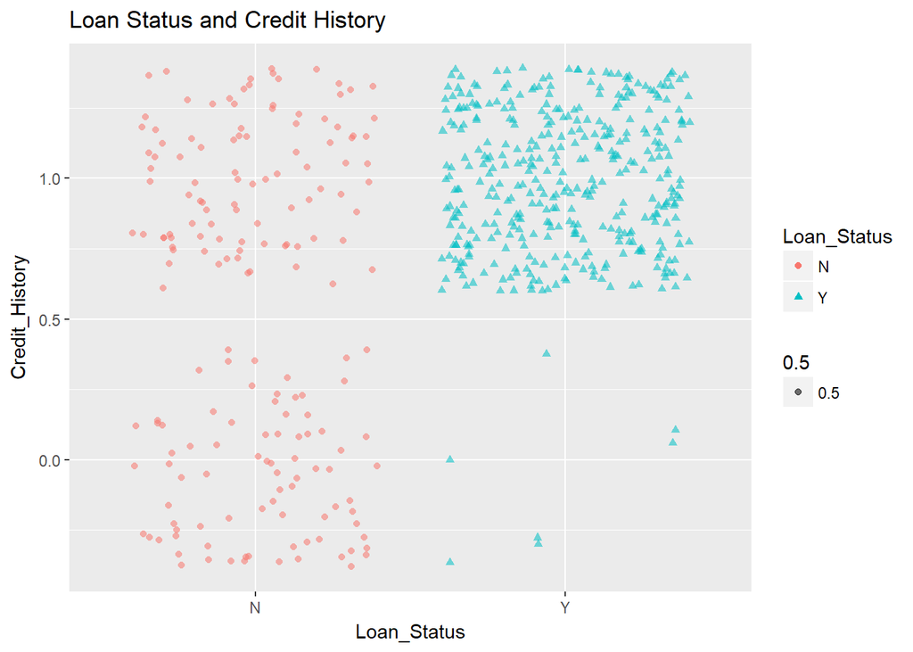

- Take Away points:-
- It should be a factor variable like yes or no etc.

### 10. Property_Area

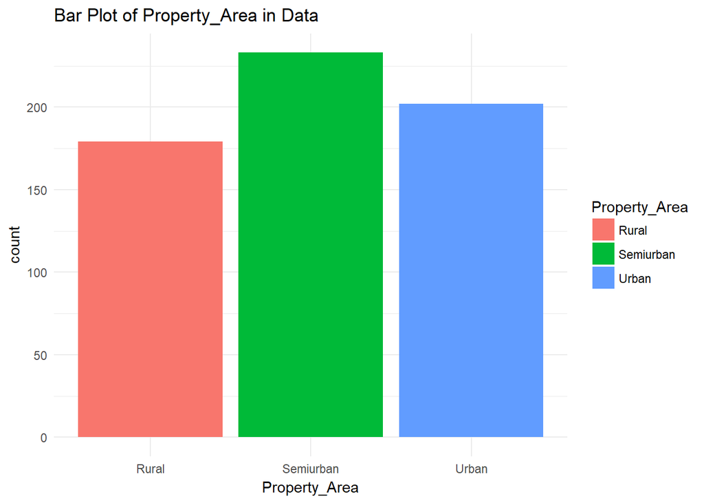

# Flow Chart of Data Imputation

[interactive chart not shown]

# Data Imputation Code

## Maratial Status Imputation

```r
#When there is "No" co-applicant income assuming as Unmarried and Married otherwise
#converting factor varibales to character later will convert back
data$Gender <- as.character(data$Gender)
data$Married <- as.character(data$Married)
data$Self_Employed <- as.character(data$Self_Employed)
data$Married[data$Married=="" & data$CoapplicantIncome==0]<-"No"
data$Married[data$Married==""]<- "Yes"
```

## Gender Imputation

```r
#Data shows if gender is male its income is more than female so
data$Dependents <- as.character(data$Dependents)
data$Gender[data$Gender=="" & data$Dependents==""] <- "Male"
```

## Dependents Imputation

```r
#When Dependents is unknown but not married then assuming no dependents
data$Dependents[data$Dependents=="" & data$Married=="No"]<- "0"
```

## Loan Amount Term Imputation

```r
#Most of the loan term is 360, so filling NA as 360 in loan amount and renaming 350 as 360 and 6 as 60 since their frequency is less and might be due to typing error while entering data
data$Loan_Amount_Term[is.na(data$Loan_Amount_Term)]<-"360"
library(car)
data$Loan_Amount_Term <- recode(data$Loan_Amount_Term,"'350'='360';'6'='60'")
```

## Self Employed Imputation

```r
#Assuming "" empty factor in self employed. As most are not self employed
data$Self_Employed[data$Self_Employed==""] <- "No"
```

## Credit History Imputation

```r
#Assuming person with no credit history as another catrgory
data$Credit_History<-recode(data$Credit_History,"NA=2")
#converting all character to factor back
data$Credit_History <- as.factor(data$Credit_History)
data$Gender <- as.factor(data$Gender)
data$Married <- as.factor(data$Married)
data$Dependents <- as.factor(data$Dependents)
data$Self_Employed <- as.factor(data$Self_Employed)
data$Loan_Amount_Term <- as.factor(data$Loan_Amount_Term)
```

## Remaining Gender & Dependents Imputation

```r
#To predict Remaining Gender by (Mode Imputation) & Dependents
levels(data$Gender)[levels(data$Gender)==""] <- "Male"
levels(data$Dependents)[levels(data$Dependents)==""] <- "0"
```

## K-Nearest Neighbours for missing Loan Amount Imputation

```r
preProcValues <- preProcess(data, method = c("knnImpute","center","scale"))
Complete_Data_processed <- predict(preProcValues, data)
```

# Data Preprocessing

## Checking Coorelation

```r
#Checking for High Coorelation among Numeric variables
cor(Complete_Data_processed[,c(7,8,9)])
```

```
##                   ApplicantIncome CoapplicantIncome LoanAmount
## ApplicantIncome         1.0000000        -0.1166046  0.5788562
## CoapplicantIncome      -0.1166046         1.0000000  0.1835371
## LoanAmount              0.5788562         0.1835371  1.0000000
```

```r
#No strong coorelation, So moving ahead.
```

## Splitting Training and Test Data set

```r
#Spliting training set into two parts based on outcome: 70% and 30%
set.seed(1)
index <- createDataPartition(Complete_Data_processed$Loan_Status, p=0.70, list=FALSE)
trainSet <- Complete_Data_processed[ index,-1]
testSet <- Complete_Data_processed[-index,-1]
```

## Creating Train control (3-fold cross validation)

```r
# Create model with default paramters
fitControl <- trainControl(method = "cv", number = 3, savePredictions = 'final', classProbs = T)
```

# Model Building using Multiple Cores

## Using 4 cores to run in parallel for model building

```r
cl <- makeCluster(4)
registerDoParallel(cl)
```

## Random Forest model #79.23% Accuracy

```r
set.seed(2)
#Training the random forest model
model_rf<-train(Loan_Status~.,data=trainSet,method='rf',trControl=fitControl,tuneLength=5)
#Predicting using random forest model
testSet$pred_rf<-predict(object = model_rf,testSet[,-13])
#Checking the accuracy of the random forest model
confusionMatrix(testSet$Loan_Status,testSet$pred_rf)
```

```
## Confusion Matrix and Statistics
##
##           Reference
## Prediction   N   Y
##          N  32  25
##          Y  13 113
##
##                Accuracy : 0.7923
##                  95% CI : (0.7263, 0.8487)
##     No Information Rate : 0.7541
##     P-Value [Acc > NIR] : 0.13135
##
##                   Kappa : 0.4863
##  Mcnemar's Test P-Value : 0.07435
##
##             Sensitivity : 0.7111
##             Specificity : 0.8188
##          Pos Pred Value : 0.5614
##          Neg Pred Value : 0.8968
##              Prevalence : 0.2459
##          Detection Rate : 0.1749
##    Detection Prevalence : 0.3115
##       Balanced Accuracy : 0.7650
##
##        'Positive' Class : N
##
```

## k-Nearest Neighbors (KNN) #74.86% Accuracy

```r
set.seed(3)
#Training the knn model
model_knn<-train(Loan_Status~.,data=trainSet,method='knn',trControl=fitControl,tuneLength=3)
#Predicting using knn model
testSet$pred_knn<-predict(object = model_knn,testSet[,-13])
#Checking the accuracy of the knn model
confusionMatrix(testSet$Loan_Status,testSet$pred_knn)
```

```
## Confusion Matrix and Statistics
##
##           Reference
## Prediction   N   Y
##          N  25  32
##          Y  14 112
##
##                Accuracy : 0.7486
##                  95% CI : (0.6793, 0.8097)
##     No Information Rate : 0.7869
##     P-Value [Acc > NIR] : 0.91008
##
##                   Kappa : 0.3585
##  Mcnemar's Test P-Value : 0.01219
##
##             Sensitivity : 0.6410
##             Specificity : 0.7778
##          Pos Pred Value : 0.4386
##          Neg Pred Value : 0.8889
##              Prevalence : 0.2131
##          Detection Rate : 0.1366
##    Detection Prevalence : 0.3115
##       Balanced Accuracy : 0.7094
##
##        'Positive' Class : N
##
```

## Logistic Regression #86.34% Accuracy

```r
set.seed(4)
#Training the Logistic regression model
model_lr<-train(Loan_Status~.,data=trainSet,method='glm',trControl=fitControl,tuneLength=3)
#Predicting using Logistic regression model
testSet$pred_lr<-predict(object = model_lr,testSet[,-13])
#Checking the accuracy of the Logistic regression model
confusionMatrix(testSet$Loan_Status,testSet$pred_lr)
```

```
## Confusion Matrix and Statistics
##
##           Reference
## Prediction   N   Y
##          N  35  22
##          Y   3 123
##
##                Accuracy : 0.8634
##                  95% CI : (0.805, 0.9096)
##     No Information Rate : 0.7923
##     P-Value [Acc > NIR] : 0.0089345
##
##                   Kappa : 0.6495
##  Mcnemar's Test P-Value : 0.0003182
##
##             Sensitivity : 0.9211
##             Specificity : 0.8483
##          Pos Pred Value : 0.6140
##          Neg Pred Value : 0.9762
##              Prevalence : 0.2077
##          Detection Rate : 0.1913
##    Detection Prevalence : 0.3115
##       Balanced Accuracy : 0.8847
##
##        'Positive' Class : N
##
```

## SVM (Linear Kernel) #86.34% Accuracy

```r
set.seed(5)
#Training the SVM using Linear Kernel
model_svm<-train(Loan_Status~.,data=trainSet,method='svmLinear',trControl=fitControl,tuneLength=3)
#Predicting using SVM using Linear Kernel
testSet$pred_svm<-predict(object = model_svm,testSet[,-13])
#Checking the accuracy of the svm model
confusionMatrix(testSet$Loan_Status,testSet$pred_svm)
```

```
## Confusion Matrix and Statistics
##
##           Reference
## Prediction   N   Y
##          N  34  23
##          Y   2 124
##
##                Accuracy : 0.8634
##                  95% CI : (0.805, 0.9096)
##     No Information Rate : 0.8033
##     P-Value [Acc > NIR] : 0.02193
##
##                   Kappa : 0.6458
##  Mcnemar's Test P-Value : 6.334e-05
##
##             Sensitivity : 0.9444
##             Specificity : 0.8435
##          Pos Pred Value : 0.5965
##          Neg Pred Value : 0.9841
##              Prevalence : 0.1967
##          Detection Rate : 0.1858
##    Detection Prevalence : 0.3115
##       Balanced Accuracy : 0.8940
##
##        'Positive' Class : N
##
```

## Neural network & Tuning #86.34% Accuracy

```r
# Training the Neural network model
model_nn <- train(Loan_Status ~ ., data = trainSet, method = "nnet", trControl = fitControl,
    tuneLength = 3)
# predict using Neural network model
testSet$pred_nn <- predict(model_nn, testSet[, -13])
# Checking the accuracy of the Neural network model
confusionMatrix(testSet$Loan_Status, testSet$pred_nn)
```

```
## Confusion Matrix and Statistics
##
##           Reference
## Prediction   N   Y
##          N  35  22
##          Y   3 123
##
##                Accuracy : 0.8634
##                  95% CI : (0.805, 0.9096)
##     No Information Rate : 0.7923
##     P-Value [Acc > NIR] : 0.0089345
##
##                   Kappa : 0.6495
##  Mcnemar's Test P-Value : 0.0003182
##
##             Sensitivity : 0.9211
##             Specificity : 0.8483
##          Pos Pred Value : 0.6140
##          Neg Pred Value : 0.9762
##              Prevalence : 0.2077
##          Detection Rate : 0.1913
##    Detection Prevalence : 0.3115
##       Balanced Accuracy : 0.8847
##
##        'Positive' Class : N
##
```

```r
# tune nueral netwrok #86.34% Accuracy
my.grid <- expand.grid(.decay = c(0.5, 0.1), .size = c(1:3))
model_nn_tune <- train(Loan_Status ~ ., data = trainSet, method = "nnet", trControl = fitControl,
    tuneLength = 3, tuneGrid = my.grid, trace = F)
testSet$pred_nn_tune <- predict(model_nn_tune, testSet[, -13])
# Checking the accuracy of the tuned Neural network model
confusionMatrix(testSet$Loan_Status, testSet$pred_nn_tune)
```

```
## Confusion Matrix and Statistics
##
##           Reference
## Prediction   N   Y
##          N  35  22
##          Y   3 123
##
##                Accuracy : 0.8634
##                  95% CI : (0.805, 0.9096)
##     No Information Rate : 0.7923
##     P-Value [Acc > NIR] : 0.0089345
##
##                   Kappa : 0.6495
##  Mcnemar's Test P-Value : 0.0003182
##
##             Sensitivity : 0.9211
##             Specificity : 0.8483
##          Pos Pred Value : 0.6140
##          Neg Pred Value : 0.9762
##              Prevalence : 0.2077
##          Detection Rate : 0.1913
##    Detection Prevalence : 0.3115
##       Balanced Accuracy : 0.8847
##
##        'Positive' Class : N
##
```

## Stopping Parallel Cluster

```r
stopCluster(cl)
registerDoSEQ()
```

# Conclusion

### Will use Logistic Regression for this dataset as the accuracy is same for Logistic Regression and SVM and Neural network, as time required to train a logistic regression model is less than svm or neural network model.